# Лабораторная работа №4

Операционные системы

Терещенкова М. В.

Российский университет дружбы народов, Москва, Россия

08 марта 2025

## Цель работы

Получение навыков правильной работы с репозиториями git.

## Задание

- Выполнить работу для тестового репозитория.
- Преобразовать рабочий репозиторий в репозиторий с git-flow и conventional commits.

## Теоретическое введение

**Общая информация:**

Gitflow Workflow опубликована и популяризована Винсентом Дриссеном.

Gitflow Workflow предполагает выстраивание строгой модели ветвления с учётом выпуска проекта.

Данная модель отлично подходит для организации рабочего процесса на основе релизов.

Работа по модели Gitflow включает создание отдельной ветки для исправлений ошибок в рабочей среде.

Последовательность действий при работе по модели Gitflow:

Из ветки master создаётся ветка develop.

Из ветки develop создаётся ветка release.

Из ветки develop создаются ветки feature.

Когда работа над веткой feature завершена, она сливается с веткой develop.

Когда работа над веткой релиза release завершена, она сливается в ветки develop и master.

Если в master обнаружена проблема, из master создаётся ветка hotfix.

Когда работа над веткой исправления hotfix завершена, она сливается в ветки develop и master.

## Выполнение лабораторной работы

**Установка git-flow**

Для установки git-flow в Fedora был использован репозиторий Copr. После успешной установки была проверена работоспособность git-flow.

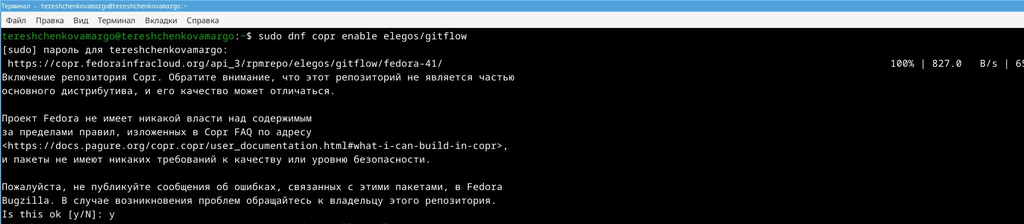

Установка git-flow

## Выполнение лабораторной работы

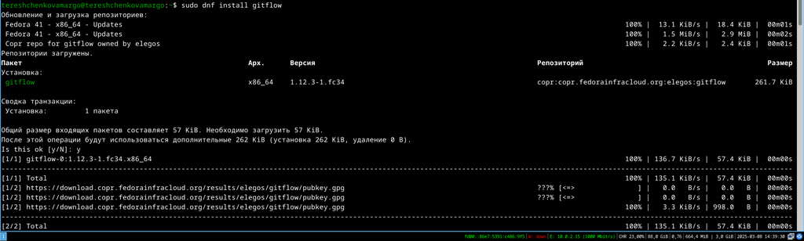

Установка git-flow.2

## Выполнение лабораторной работы

**Установка Node.js**

Для поддержки инструментов семантического версионирования и стандартизированных коммитов был установлен Node.js вместе с pnpm.

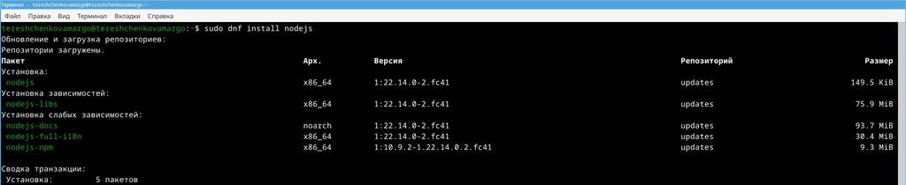

Установка Node.js

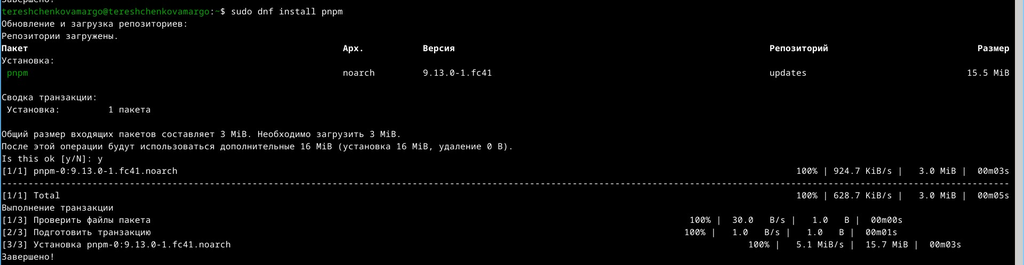

Установка Node.js.2

## Выполнение лабораторной работы

**Настройка Node.js**

Добавлен каталог с исполняемыми файлами в PATH с помощью команд **pnpm setup**, **source ~/.bashrc**

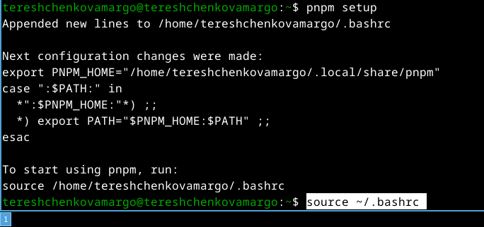

Добавление каталога

## Выполнение лабораторной работы

После этого были установлены утилиты: **commitizen** — для стандартизированных коммитов;**standard-changelog** — для генерации журнала изменений.

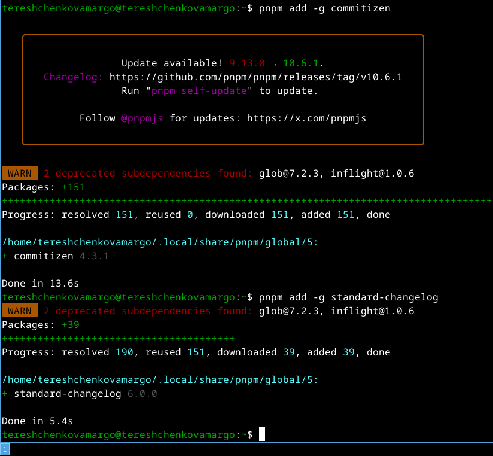

Установление утилитов

## Выполнение лабораторной работы

**Практическое использование Git**

**Создание и подключение репозитория**

На GitHub был создан репозиторий git-extended, после чего выполнена его инициализация и первый коммит.

[figure not shown]

Репозиторий на GitHub

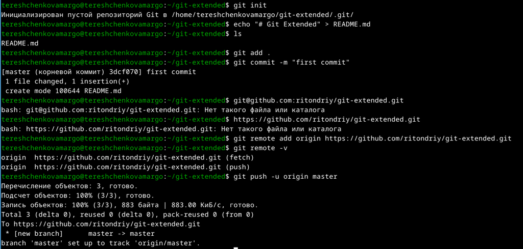

## Выполнение лабораторной работы

**Настройка формата коммитов**

Был инициализирован package.json с настройками:

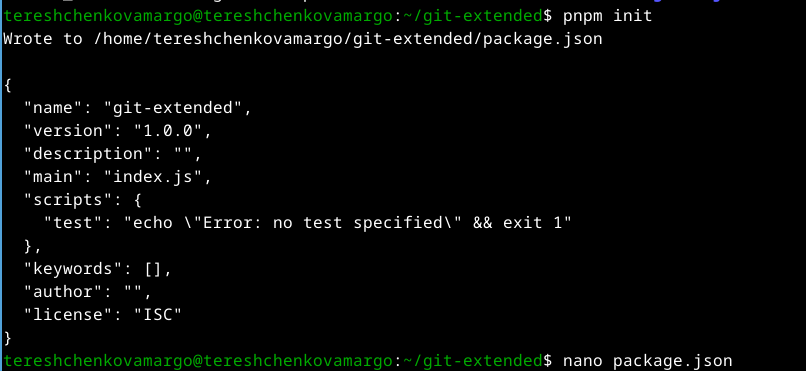

Инициализация package.json

## Выполнение лабораторной работы

Добавлена конфигурация для commitizen:

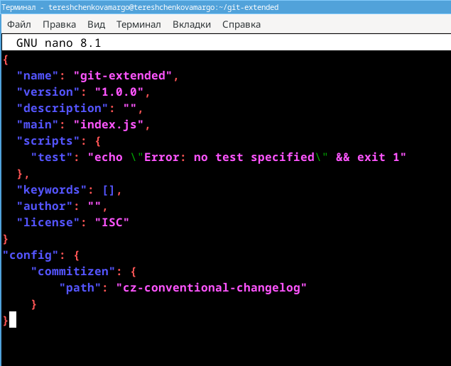

Добавление конфигурации

## Выполнение лабораторной работы

После этого были добавлены файлы и выполнен коммит через git cz:

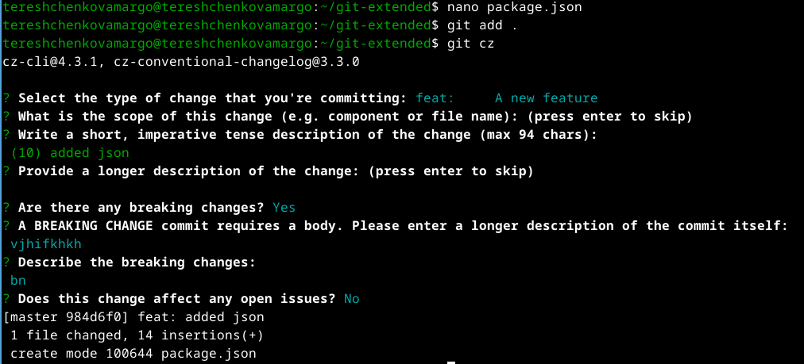

Добавление файлов и выполнение коммита

## Выполнение лабораторной работы

**Конфигурация git-flown**

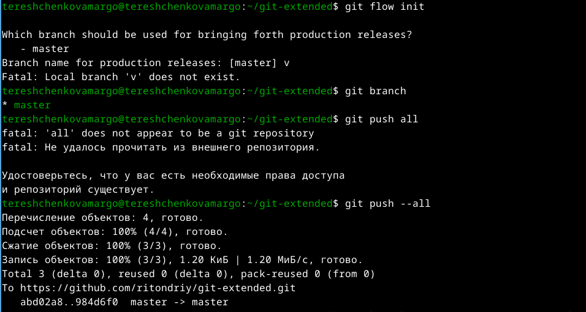

## Выполнение лабораторной работы

**Создание релиза**

Создаю релиз 1.0.0;

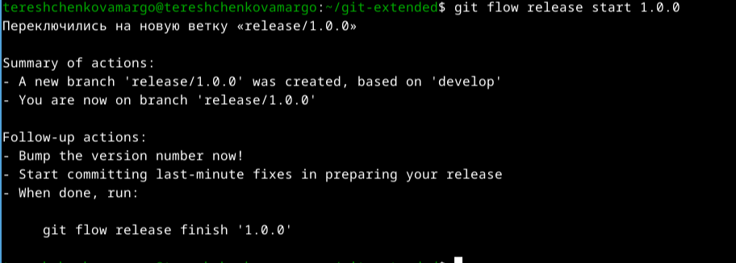

Создание релиза 1.0.0

## Выполнение лабораторной работы

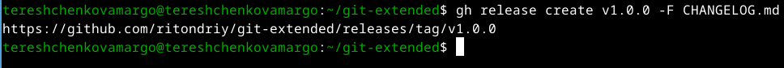

Создание релиза на GitHub

## Выполнение лабораторной работы

**Работа с репозиторием**

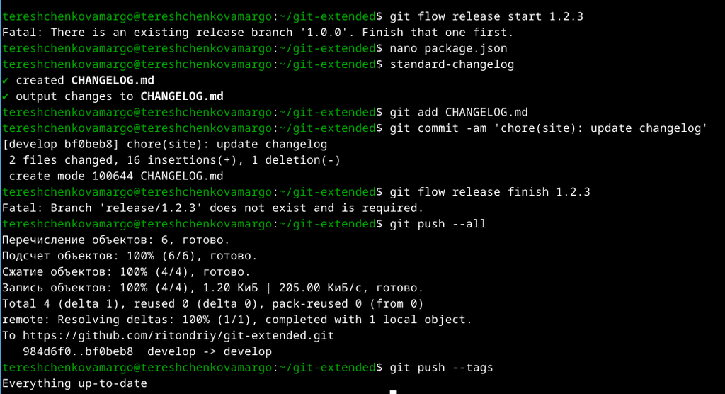

Работа с репозиторием

## Выводы

Получила навыки правильной работы с репозиториями git.

# УРАА! С 8-ЫМ МАРТА!!